# BodyFat prediction with multiple linear regression - R

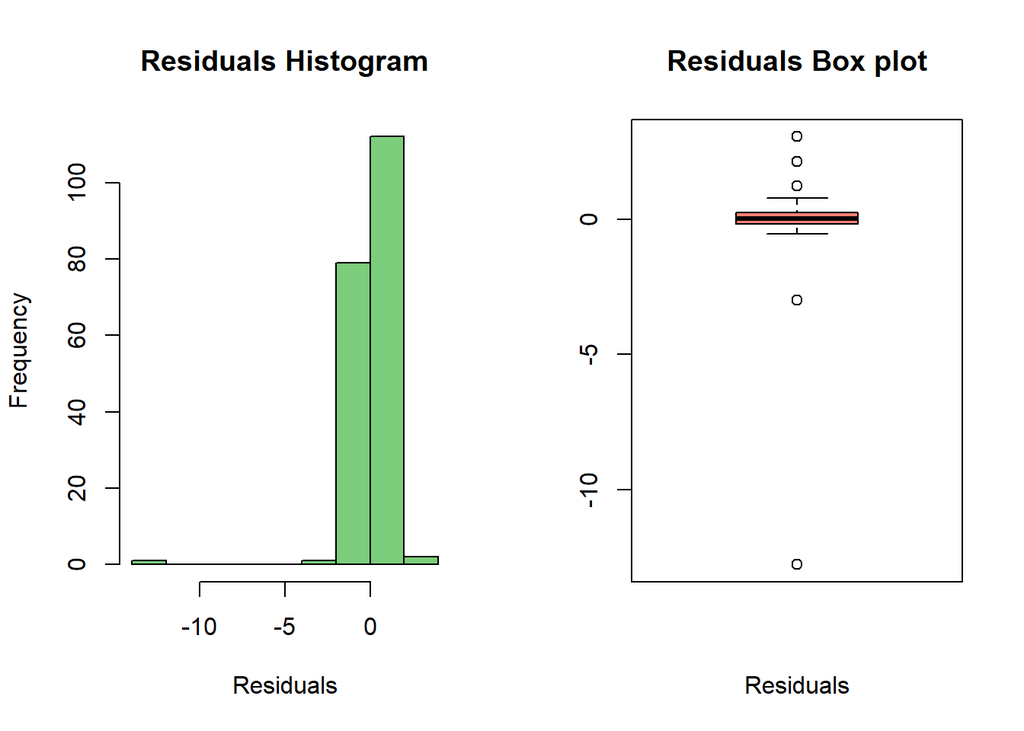

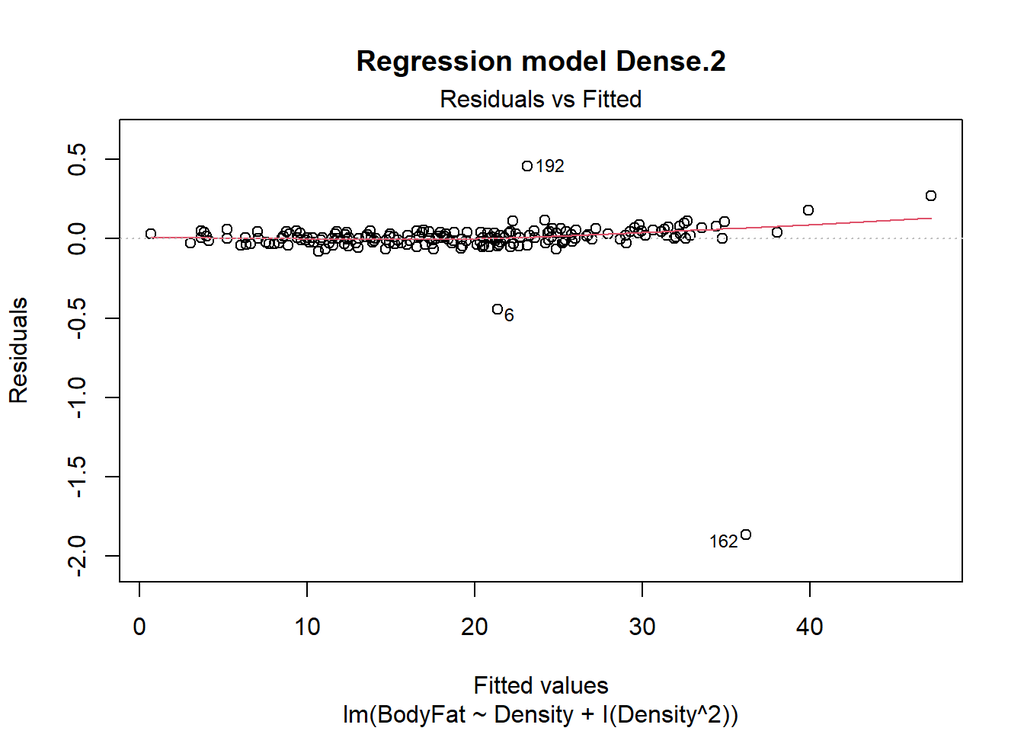

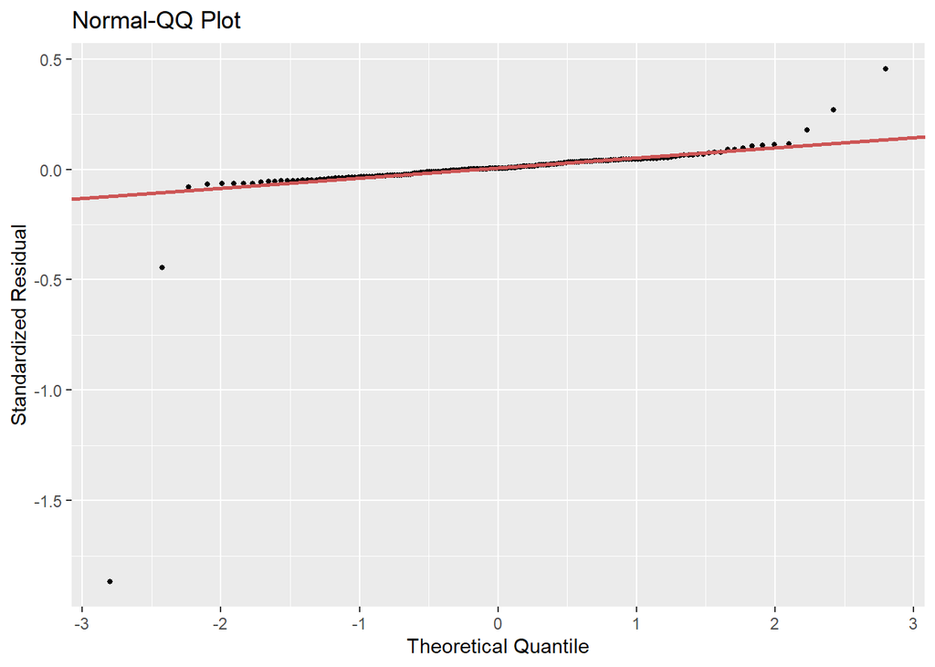

The residual plot is significantly improved. Nevertheless, analyzing this graph and the residual box plot, we note the presence of some anomalous value. Let’s remove them and fit the model again.

```
##
## Call:
## lm(formula = BodyFat ~ Density + I(Density^2), data = bodyfat.train.density)
##
## Residuals:
##       Min        1Q    Median        3Q       Max
## -0.074480 -0.026881  0.001232  0.027293  0.069735
##
## Coefficients:
##               Estimate Std. Error t value Pr(>|t|)
## (Intercept)    951.262      7.208  131.97   <2e-16 ***
## Density      -1321.658     13.667  -96.70   <2e-16 ***
## I(Density^2)   415.342      6.477   64.12   <2e-16 ***
## ---
## Signif. codes:  0 '***' 0.001 '**' 0.01 '*' 0.05 '.' 0.1 ' ' 1
##
## Residual standard error: 0.03352 on 183 degrees of freedom
## Multiple R-squared:      1,  Adjusted R-squared:      1
## F-statistic: 5.58e+06 on 2 and 183 DF,  p-value: < 2.2e-16
```

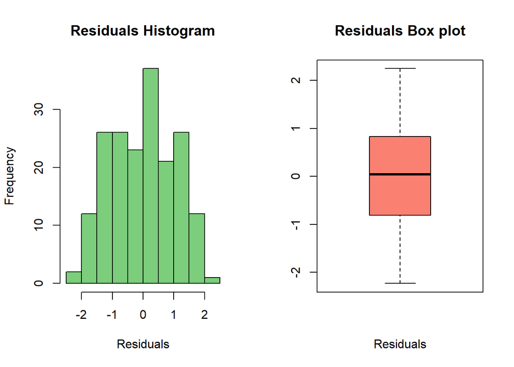

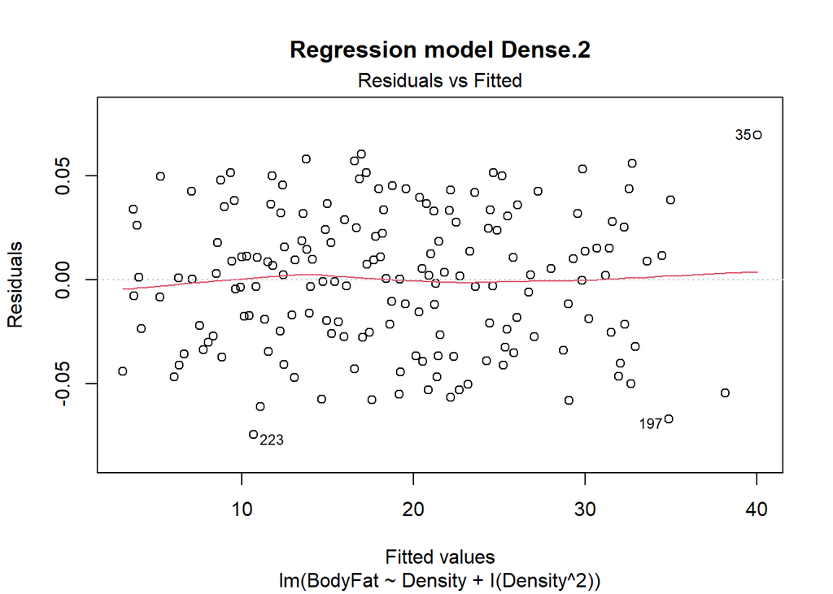

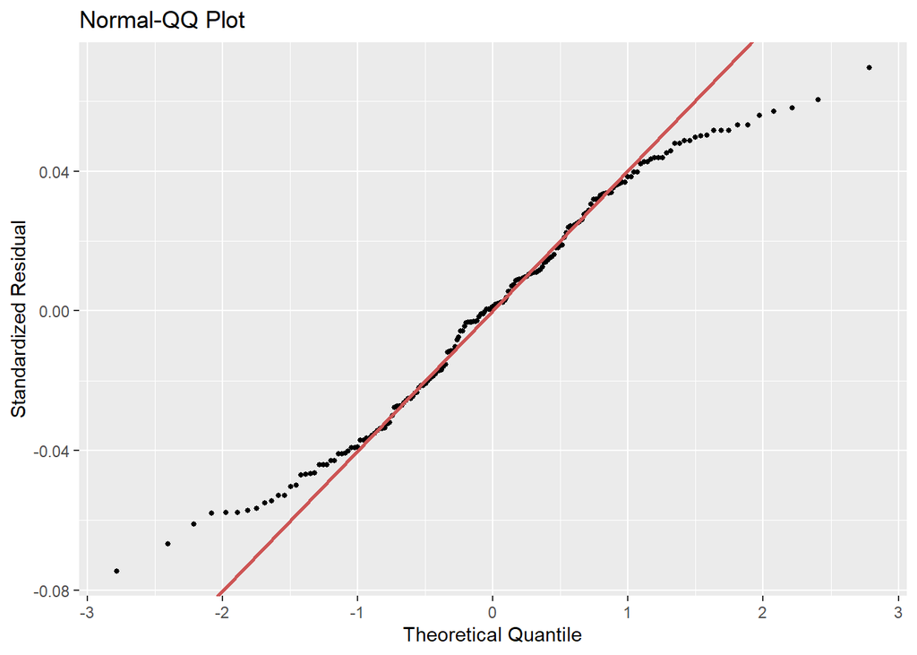

By removing the outliers, we get an R-square index of 100%. This means that *Density* alone accounts for 100% of the total variability. Also, the residuals plot is now very centered around zero. For these reasons we expect a high predictive capacity.

```
## [1] "Values correctly predicted with 1 % margin:"
## [1] "49/50"
## [1] "Percentage: 98"
```

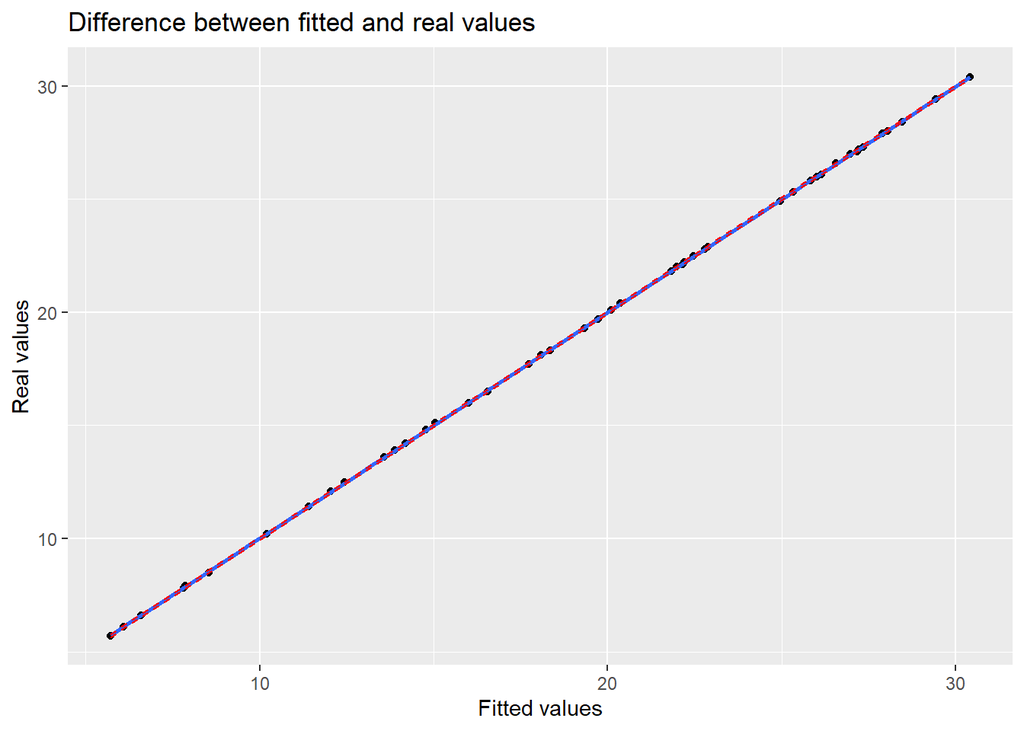

The predictive capacity reaches almost 100%, as we can also see from the graph, in which the predicted values coincide almost perfectly with the real values.

# 6 CONCLUSION

In summary, we carried out the descriptive analysis of the BodyFat dataset, thanks to which it was verified that the percentage of bodyfat is dependent in mean on the age group of an individual. Additionally, a linear regression model was built to predict body fat percentage. The model constructed was then compared with the model having as its only covariate the variable *Density*, which (obviously) has a very high precision, but it makes use of a regressor (*Density*) which is much more difficult to obtain than the less precise common body measurements. The regression model having the latter as covariates is however quite reliable, with an R-squared index of about 75% and, above all, a predictive capacity of 86% with a tolerance of 25%, which falls “only” to 72% in case of tolerance of 5%. In conclusion, this model represents a good compromise between performance and complexity of the measurements.

# APPENDIX: FUNCTIONS IMPLEMENTED

For the purposes of a better understanding and an optimization of the code, various functions have been implemented. In particular:

- *udm(var_name)*: Purely accessory function that associates its own unit of measurement to each variable in the graphs.
- Unit conversion:
  - *from_inches_to_cm(x)*: Inches -> Centimeters.
  - *from_pnd_to_kg(x)*: Pounds -> Kilograms.
- *date_scatter(xvar, yvar, dataset)*: Function that takes a variable *xvar* as input and returns a grob with the informations necessary to create the relative scatter plot, with respect to the target *BodyFat* (*yvar*).
- *date_box(xvar)*: Function that takes a variable *xvar* as input and returns a grob with the informations necessary to create the relative box plot.
- *partial_correlation(x, y, z)*: Function that returns the partial correlation between x and y, given z.
- *graphs_(model, residuals, name)*: Function which, given a model, returns the graphs concerning the analysis of the linear model with residual annexes.
- *prediction(model, err)*: Function that returns the percentage of test set values correctly predicted by the model passed as a parameter. In particular, the percentage is calculated considering the ratio between correct forecasts and total forecasts, where by “right” we mean an error margin equal to *err*.
- *prediction_graph(model)*: Function that, given a model, returns the graph concerning the difference between predicted and actual values, based on the test set.